# Tugas Pertemuan 5

Raziqizzan Putrandi - G1401211040

```r
library(ggplot2)
library(tsibble)
library(tseries)
library(MASS)
```

# Input data

```r
library(readxl)
dataSmekah<- read_excel("C:\\Users\\User\\Documents\\raziq\\semseter 5\\MPDW\\praktikum\\data suhu mekkah.xlsx",
    sheet = "Sheet1")
```

# Data FULL

### Ubah data ke ts

```r
dataSmekah.ts <- ts(dataSmekah$`suhu mekkah`)
```

### Membuat plot time series

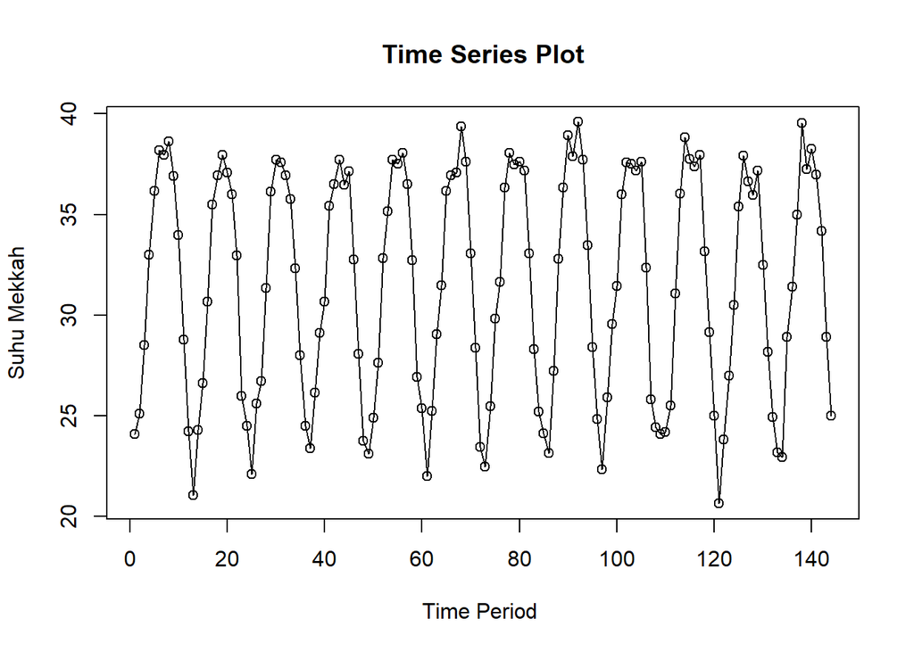

```r
ts.plot(dataSmekah.ts, xlab="Time Period ", ylab="Suhu Mekkah",
        main = "Time Series Plot")
points(dataSmekah.ts)
```

### Plot ACF

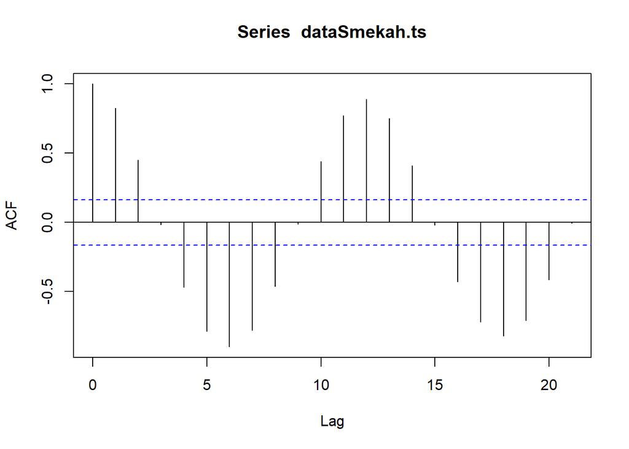

```r
acf(dataSmekah.ts)
```

Berdasarkan plot ACF, terlihat bahwa plot ACF pada data tersebut cenderung *tails off* dan membentuk gelombang sinus.

### Uji ADF

```r
tseries::adf.test(dataSmekah.ts)
```

```
##
##  Augmented Dickey-Fuller Test
##
## data:  dataSmekah.ts
## Dickey-Fuller = -11.127, Lag order = 5, p-value = 0.01
## alternative hypothesis: stationary
```

$H_0$ : Data tidak stasioner dalam rataan

$H_1$ : Data stasioner dalam rataan

Berdasarkan uji ADF tersebut, didapat *p-value* sebesar 0.01 yang lebih kecil dari taraf nyata 5% sehingga tolak $H_0$ dan menandakan bahwa data stasioner dalam rataan. Hal ini sesuai dengan hasil eksplorasi menggunakan plot time series dan plot ACF.

### Plot Box-Cox

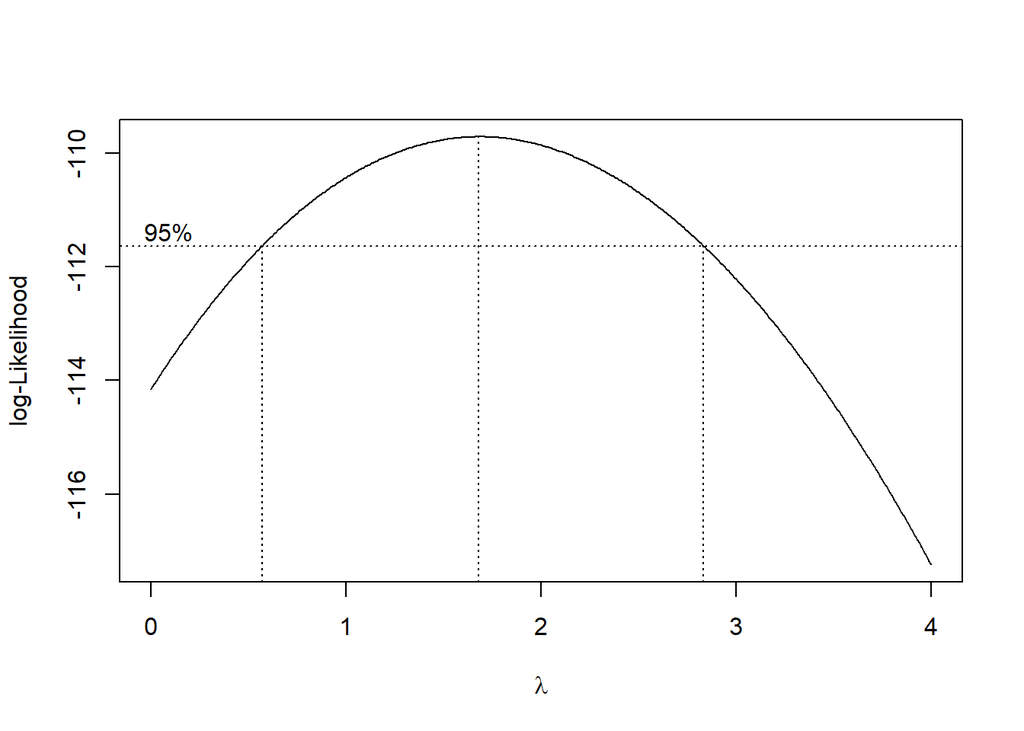

```r
index <- seq(1:144)
bc = boxcox(dataSmekah.ts~index, lambda = seq(0,4,by=0.01))
```

```r
#Nilai Rounded Lambda
lambda <- bc$x[which.max(bc$y)]
lambda
```

```
## [1] 1.68
```

```r
#SK
bc$x[bc$y > max(bc$y) - 1/2 * qchisq(.95,1)]
```

```
##   [1] 0.57 0.58 0.59 0.60 0.61 0.62 0.63 0.64 0.65 0.66 0.67 0.68 0.69 0.70 0.71
##  [16] 0.72 0.73 0.74 0.75 0.76 0.77 0.78 0.79 0.80 0.81 0.82 0.83 0.84 0.85 0.86
##  [31] 0.87 0.88 0.89 0.90 0.91 0.92 0.93 0.94 0.95 0.96 0.97 0.98 0.99 1.00 1.01
##  [46] 1.02 1.03 1.04 1.05 1.06 1.07 1.08 1.09 1.10 1.11 1.12 1.13 1.14 1.15 1.16
##  [61] 1.17 1.18 1.19 1.20 1.21 1.22 1.23 1.24 1.25 1.26 1.27 1.28 1.29 1.30 1.31
##  [76] 1.32 1.33 1.34 1.35 1.36 1.37 1.38 1.39 1.40 1.41 1.42 1.43 1.44 1.45 1.46
##  [91] 1.47 1.48 1.49 1.50 1.51 1.52 1.53 1.54 1.55 1.56 1.57 1.58 1.59 1.60 1.61
## [106] 1.62 1.63 1.64 1.65 1.66 1.67 1.68 1.69 1.70 1.71 1.72 1.73 1.74 1.75 1.76
## [121] 1.77 1.78 1.79 1.80 1.81 1.82 1.83 1.84 1.85 1.86 1.87 1.88 1.89 1.90 1.91
## [136] 1.92 1.93 1.94 1.95 1.96 1.97 1.98 1.99 2.00 2.01 2.02 2.03 2.04 2.05 2.06
## [151] 2.07 2.08 2.09 2.10 2.11 2.12 2.13 2.14 2.15 2.16 2.17 2.18 2.19 2.20 2.21
## [166] 2.22 2.23 2.24 2.25 2.26 2.27 2.28 2.29 2.30 2.31 2.32 2.33 2.34 2.35 2.36
## [181] 2.37 2.38 2.39 2.40 2.41 2.42 2.43 2.44 2.45 2.46 2.47 2.48 2.49 2.50 2.51
## [196] 2.52 2.53 2.54 2.55 2.56 2.57 2.58 2.59 2.60 2.61 2.62 2.63 2.64 2.65 2.66
## [211] 2.67 2.68 2.69 2.70 2.71 2.72 2.73 2.74 2.75 2.76 2.77 2.78 2.79 2.80 2.81
## [226] 2.82 2.83
```

Gambar di atas menunjukkan nilai *rounded value* ($\lambda$) optimum sebesar **1.68** dan pada selang kepercayaan 95% nilai memiliki batas bawah **0.57** dan batas atas **2.83**. Selang tersebut memuat nilai satu sehingga dapat dikatakan bahwa data bangkitan stasioner dalam ragam.

Kesimpulan: Maka data tersebut stasioner dalam rataan dan ragam

# Bagian 1

```r
dataSmekah.ts1 <- dataSmekah$`suhu mekkah`[1:73] |> ts()
mean(dataSmekah.ts1)
```

```
## [1] 31.33863
```

```r
var(dataSmekah.ts1)
```

```
## [1] 31.23127
```

### Membuat plot time series

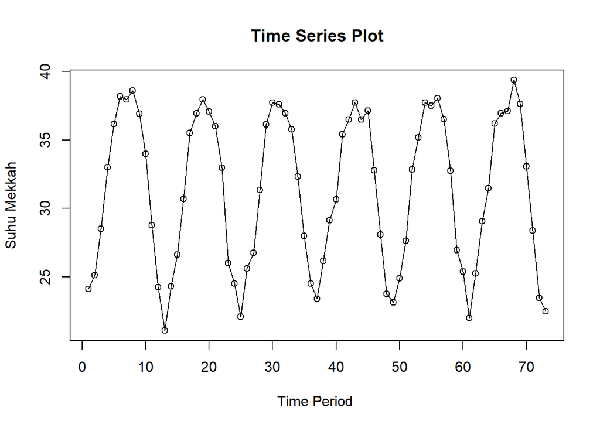

```r
ts.plot(dataSmekah.ts1, xlab="Time Period ", ylab="Suhu Mekkah",
        main = "Time Series Plot")
points(dataSmekah.ts1)
```

### Plot ACF

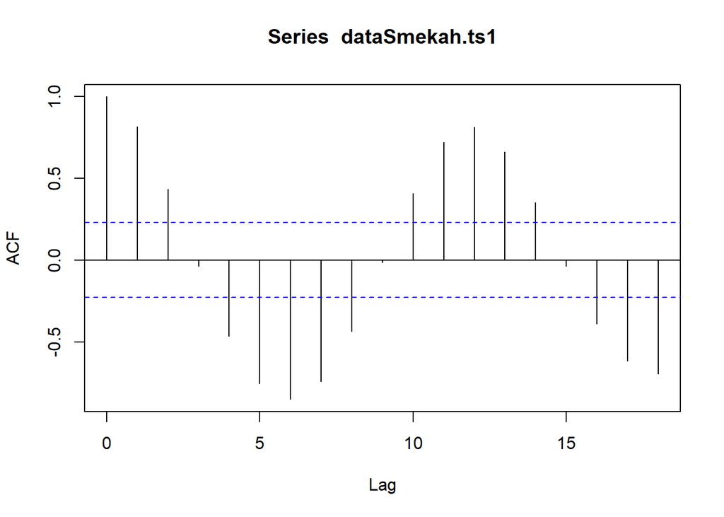

```r
acf(dataSmekah.ts1)
```

Berdasarkan plot ACF, terlihat bahwa plot ACF pada data tersebut cenderung *tails off* dan membentuk gelombang sinus.

### Uji ADF

```r
tseries::adf.test(dataSmekah.ts1)
```

```
##
##  Augmented Dickey-Fuller Test
##
## data:  dataSmekah.ts1
## Dickey-Fuller = -7.4267, Lag order = 4, p-value = 0.01
## alternative hypothesis: stationary
```

$H_0$ : Data tidak stasioner dalam rataan

$H_1$ : Data stasioner dalam rataan

Berdasarkan uji ADF tersebut, didapat *p-value* sebesar 0.01 yang lebih kecil dari taraf nyata 5% sehingga tolak $H_0$ dan menandakan bahwa data stasioner dalam rataan. Hal ini sesuai dengan hasil eksplorasi menggunakan plot time series dan plot ACF.

### Plot Box-Cox

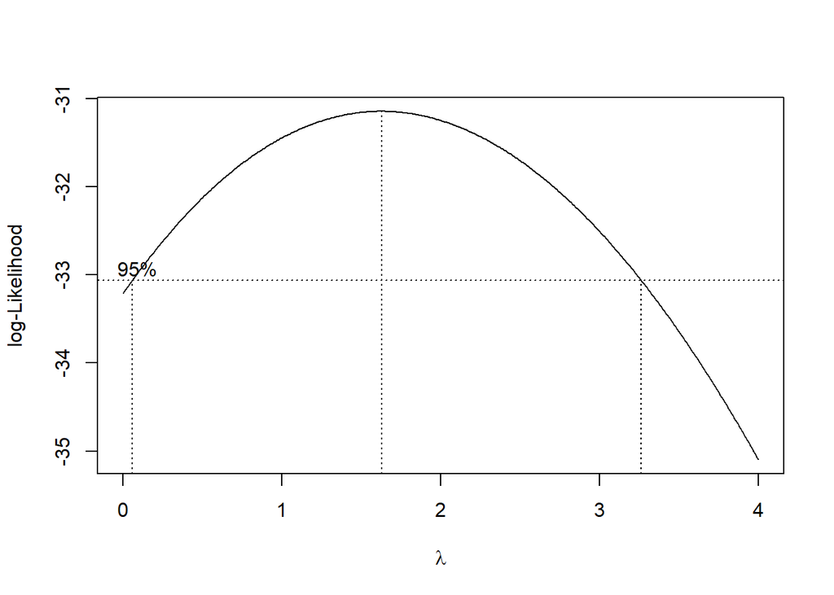

```r
index.1 <- seq(1:73)
bc.1 = boxcox(dataSmekah.ts1~index.1, lambda = seq(0,4,by=0.01))
```

```r
#Nilai Rounded Lambda
lambda.1 <- bc.1$x[which.max(bc.1$y)]
lambda.1
```

```
## [1] 1.63
```

```r
#SK
bc.1$x[bc.1$y > max(bc.1$y) - 1/2 * qchisq(.95,1)]
```

```
##   [1] 0.06 0.07 0.08 0.09 0.10 0.11 0.12 0.13 0.14 0.15 0.16 0.17 0.18 0.19 0.20
##  [16] 0.21 0.22 0.23 0.24 0.25 0.26 0.27 0.28 0.29 0.30 0.31 0.32 0.33 0.34 0.35
##  [31] 0.36 0.37 0.38 0.39 0.40 0.41 0.42 0.43 0.44 0.45 0.46 0.47 0.48 0.49 0.50
##  [46] 0.51 0.52 0.53 0.54 0.55 0.56 0.57 0.58 0.59 0.60 0.61 0.62 0.63 0.64 0.65
##  [61] 0.66 0.67 0.68 0.69 0.70 0.71 0.72 0.73 0.74 0.75 0.76 0.77 0.78 0.79 0.80
##  [76] 0.81 0.82 0.83 0.84 0.85 0.86 0.87 0.88 0.89 0.90 0.91 0.92 0.93 0.94 0.95
##  [91] 0.96 0.97 0.98 0.99 1.00 1.01 1.02 1.03 1.04 1.05 1.06 1.07 1.08 1.09 1.10
## [106] 1.11 1.12 1.13 1.14 1.15 1.16 1.17 1.18 1.19 1.20 1.21 1.22 1.23 1.24 1.25
## [121] 1.26 1.27 1.28 1.29 1.30 1.31 1.32 1.33 1.34 1.35 1.36 1.37 1.38 1.39 1.40
## [136] 1.41 1.42 1.43 1.44 1.45 1.46 1.47 1.48 1.49 1.50 1.51 1.52 1.53 1.54 1.55
## [151] 1.56 1.57 1.58 1.59 1.60 1.61 1.62 1.63 1.64 1.65 1.66 1.67 1.68 1.69 1.70
## [166] 1.71 1.72 1.73 1.74 1.75 1.76 1.77 1.78 1.79 1.80 1.81 1.82 1.83 1.84 1.85
## [181] 1.86 1.87 1.88 1.89 1.90 1.91 1.92 1.93 1.94 1.95 1.96 1.97 1.98 1.99 2.00
## [196] 2.01 2.02 2.03 2.04 2.05 2.06 2.07 2.08 2.09 2.10 2.11 2.12 2.13 2.14 2.15
## [211] 2.16 2.17 2.18 2.19 2.20 2.21 2.22 2.23 2.24 2.25 2.26 2.27 2.28 2.29 2.30
## [226] 2.31 2.32 2.33 2.34 2.35 2.36 2.37 2.38 2.39 2.40 2.41 2.42 2.43 2.44 2.45
## [241] 2.46 2.47 2.48 2.49 2.50 2.51 2.52 2.53 2.54 2.55 2.56 2.57 2.58 2.59 2.60
## [256] 2.61 2.62 2.63 2.64 2.65 2.66 2.67 2.68 2.69 2.70 2.71 2.72 2.73 2.74 2.75
## [271] 2.76 2.77 2.78 2.79 2.80 2.81 2.82 2.83 2.84 2.85 2.86 2.87 2.88 2.89 2.90
## [286] 2.91 2.92 2.93 2.94 2.95 2.96 2.97 2.98 2.99 3.00 3.01 3.02 3.03 3.04 3.05
## [301] 3.06 3.07 3.08 3.09 3.10 3.11 3.12 3.13 3.14 3.15 3.16 3.17 3.18 3.19 3.20
## [316] 3.21 3.22 3.23 3.24 3.25 3.26
```

Gambar di atas menunjukkan nilai *rounded value* ($\lambda$) optimum sebesar **1.63** dan pada selang kepercayaan 95% nilai memiliki batas bawah **0.06** dan batas atas **3.26**. Selang tersebut memuat nilai satu sehingga dapat dikatakan bahwa data bangkitan stasioner dalam ragam.

Kesimpulan partisi 1: Maka data tersebut stasioner dalam rataan dan ragam

# Bagian 2

```r
dataSmekah.ts2 <- dataSmekah$`suhu mekkah`[74:144] |> ts()
mean(dataSmekah.ts2)
```

```
## [1] 31.75789
```

```r
var(dataSmekah.ts2)
```

```
## [1] 31.59313
```

### Membuat plot time series

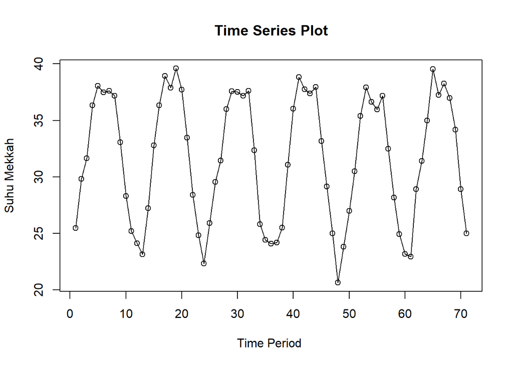

```r
ts.plot(dataSmekah.ts2, xlab="Time Period ", ylab="Suhu Mekkah",
        main = "Time Series Plot")
points(dataSmekah.ts2)
```

### Plot ACF

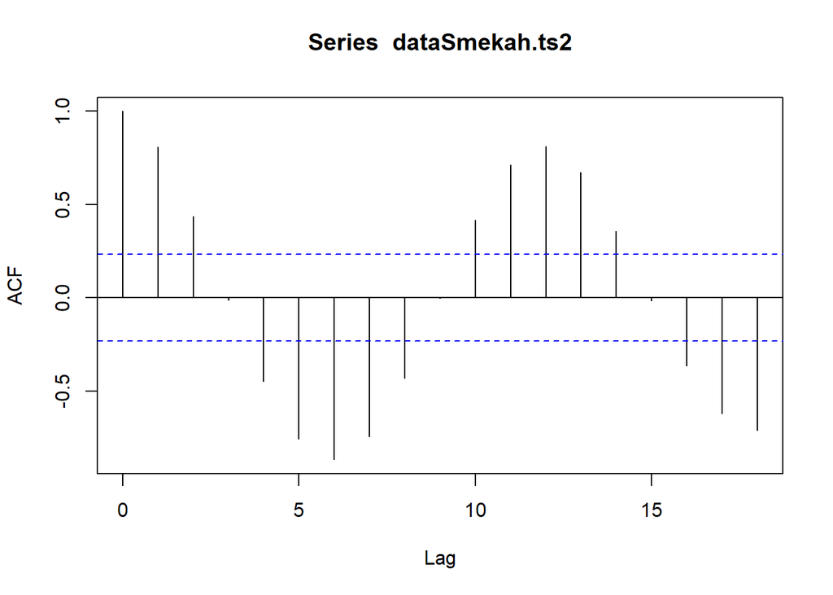

```r
acf(dataSmekah.ts2)
```

Berdasarkan plot ACF, terlihat bahwa plot ACF pada data tersebut cenderung *tails off* dan membentuk gelombang sinus.

### Uji ADF

```r
tseries::adf.test(dataSmekah.ts2)
```

```
##
##  Augmented Dickey-Fuller Test
##
## data:  dataSmekah.ts2
## Dickey-Fuller = -8.1153, Lag order = 4, p-value = 0.01
## alternative hypothesis: stationary
```

$H_0$ : Data tidak stasioner dalam rataan

$H_1$ : Data stasioner dalam rataan

Berdasarkan uji ADF tersebut, didapat *p-value* sebesar 0.01 yang lebih kecil dari taraf nyata 5% sehingga tolak $H_0$ dan menandakan bahwa data stasioner dalam rataan. Hal ini sesuai dengan hasil eksplorasi menggunakan plot time series dan plot ACF.

### Plot Box-Cox

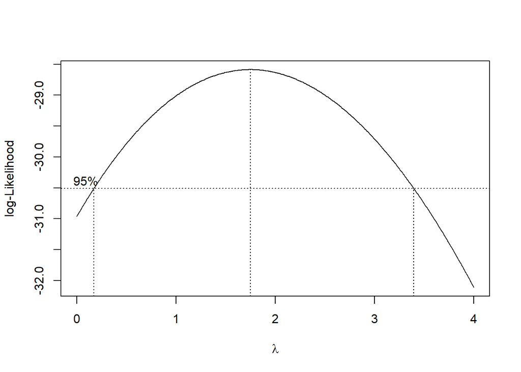

```r
index.2 <- seq(74:144)
bc.2 = boxcox(dataSmekah.ts2~index.2, lambda = seq(0,4,by=0.01))
```

```r
#Nilai Rounded Lambda
lambda.2 <- bc.2$x[which.max(bc.2$y)]
lambda.2
```

```
## [1] 1.75
```

```r
#SK
bc.2$x[bc.2$y > max(bc.2$y) - 1/2 * qchisq(.95,1)]
```

```
##   [1] 0.18 0.19 0.20 0.21 0.22 0.23 0.24 0.25 0.26 0.27 0.28 0.29 0.30 0.31 0.32
##  [16] 0.33 0.34 0.35 0.36 0.37 0.38 0.39 0.40 0.41 0.42 0.43 0.44 0.45 0.46 0.47
##  [31] 0.48 0.49 0.50 0.51 0.52 0.53 0.54 0.55 0.56 0.57 0.58 0.59 0.60 0.61 0.62
##  [46] 0.63 0.64 0.65 0.66 0.67 0.68 0.69 0.70 0.71 0.72 0.73 0.74 0.75 0.76 0.77
##  [61] 0.78 0.79 0.80 0.81 0.82 0.83 0.84 0.85 0.86 0.87 0.88 0.89 0.90 0.91 0.92
##  [76] 0.93 0.94 0.95 0.96 0.97 0.98 0.99 1.00 1.01 1.02 1.03 1.04 1.05 1.06 1.07
##  [91] 1.08 1.09 1.10 1.11 1.12 1.13 1.14 1.15 1.16 1.17 1.18 1.19 1.20 1.21 1.22
## [106] 1.23 1.24 1.25 1.26 1.27 1.28 1.29 1.30 1.31 1.32 1.33 1.34 1.35 1.36 1.37
## [121] 1.38 1.39 1.40 1.41 1.42 1.43 1.44 1.45 1.46 1.47 1.48 1.49 1.50 1.51 1.52
## [136] 1.53 1.54 1.55 1.56 1.57 1.58 1.59 1.60 1.61 1.62 1.63 1.64 1.65 1.66 1.67
## [151] 1.68 1.69 1.70 1.71 1.72 1.73 1.74 1.75 1.76 1.77 1.78 1.79 1.80 1.81 1.82
## [166] 1.83 1.84 1.85 1.86 1.87 1.88 1.89 1.90 1.91 1.92 1.93 1.94 1.95 1.96 1.97
## [181] 1.98 1.99 2.00 2.01 2.02 2.03 2.04 2.05 2.06 2.07 2.08 2.09 2.10 2.11 2.12
## [196] 2.13 2.14 2.15 2.16 2.17 2.18 2.19 2.20 2.21 2.22 2.23 2.24 2.25 2.26 2.27
## [211] 2.28 2.29 2.30 2.31 2.32 2.33 2.34 2.35 2.36 2.37 2.38 2.39 2.40 2.41 2.42
## [226] 2.43 2.44 2.45 2.46 2.47 2.48 2.49 2.50 2.51 2.52 2.53 2.54 2.55 2.56 2.57
## [241] 2.58 2.59 2.60 2.61 2.62 2.63 2.64 2.65 2.66 2.67 2.68 2.69 2.70 2.71 2.72
## [256] 2.73 2.74 2.75 2.76 2.77 2.78 2.79 2.80 2.81 2.82 2.83 2.84 2.85 2.86 2.87
## [271] 2.88 2.89 2.90 2.91 2.92 2.93 2.94 2.95 2.96 2.97 2.98 2.99 3.00 3.01 3.02
## [286] 3.03 3.04 3.05 3.06 3.07 3.08 3.09 3.10 3.11 3.12 3.13 3.14 3.15 3.16 3.17
## [301] 3.18 3.19 3.20 3.21 3.22 3.23 3.24 3.25 3.26 3.27 3.28 3.29 3.30 3.31 3.32
## [316] 3.33 3.34 3.35 3.36 3.37 3.38 3.39
```

Gambar di atas menunjukkan nilai *rounded value* ($\lambda$) optimum sebesar **1.75** dan pada selang kepercayaan 95% nilai memiliki batas bawah **0.18** dan batas atas **3.39**. Selang tersebut memuat nilai satu sehingga dapat dikatakan bahwa data bangkitan stasioner dalam ragam.

Kesimpulan partisi 2: Maka data tersebut stasioner dalam rataan dan ragam